# STA 9750 Final Project – Happiness, Income, Vacation, and Governance

## 1. Motivation

This report examines how national happiness relates to economic security (income) and time-related well-being (vacation/leisure), and adds an institutional lens via perceptions of corruption. The purpose is to compare which factors appear most strongly associated with happiness across countries.

## 2. Data Sources

- **World Happiness Report** (WHR 2025 data file): happiness (life evaluation, 3-year average), explained log GDP per capita, explained perceptions of corruption.
- **OECD Time Use**: Leisure minutes/day (LEI) as a work–life balance / time-off proxy.

## 3. Visualizations

### 3.1 Happiness vs Income

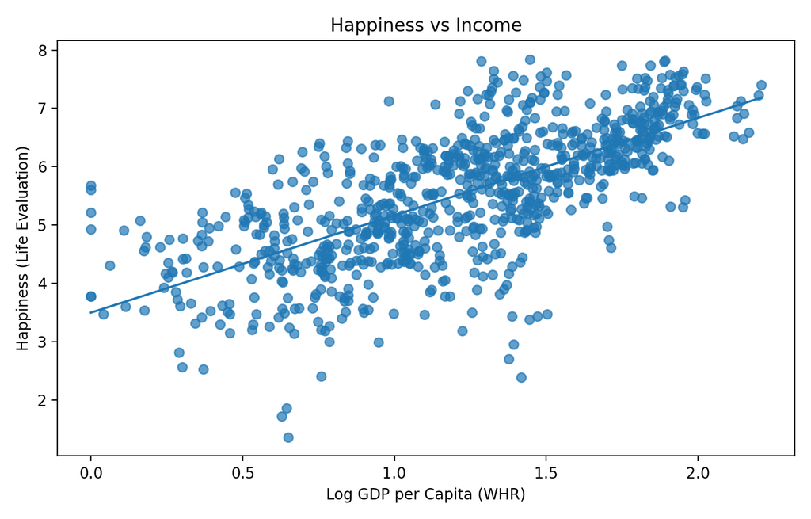

Country-year observations (WHR). Line shows a fitted linear trend.

### 3.2 Happiness vs Vacation/Leisure (Work–Life Balance Proxy)

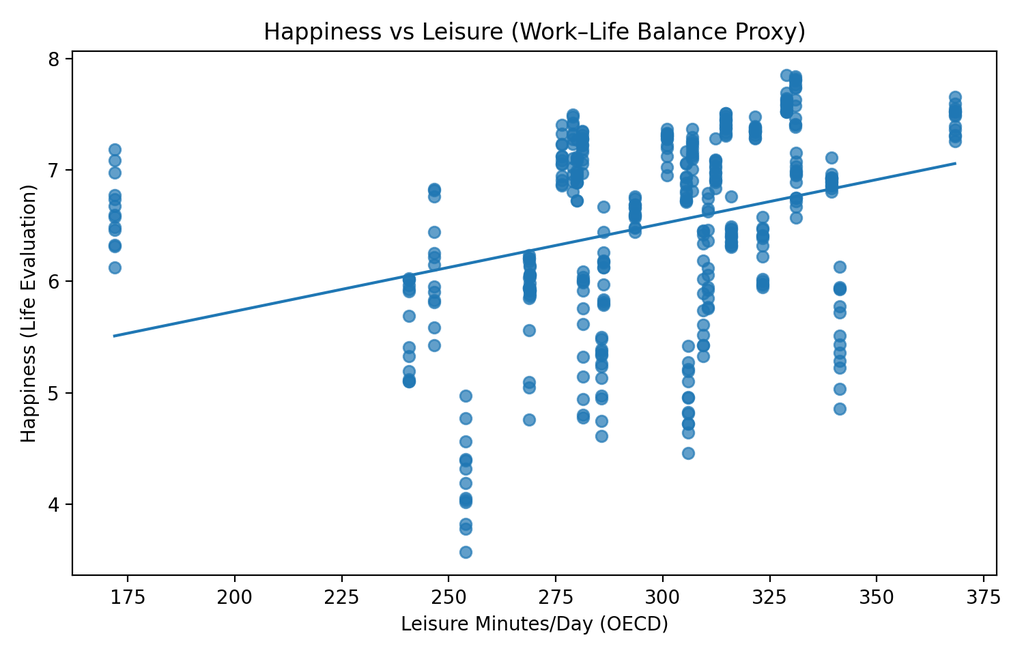

OECD leisure minutes/day merged at the country level.

**Finding:** Leisure time shows a positive association with happiness, consistent with the idea that time off and work–life balance can matter for well-being—especially after basic needs are met.

### 3.3 Happiness vs Corruption Perceptions

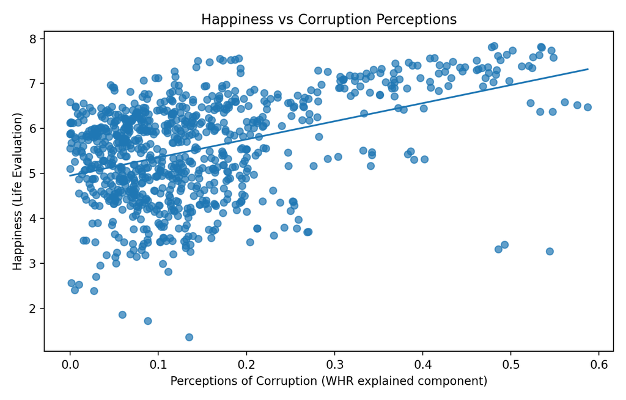

Higher values reflect stronger (more favorable) corruption-related contribution in the WHR explained components.

**Finding:** Corruption perceptions are strongly related to happiness. Countries with stronger institutional trust and lower perceived corruption tend to report higher well-being.

## 4. Correlations

|  | happiness | log_gdp_per_capita | leisure_minutes | corruption |
| --- | --- | --- | --- | --- |
| happiness | 1.00 | 0.50 | 0.36 | 0.73 |
| log_gdp_per_capita | 0.50 | 1.00 | 0.25 | 0.43 |
| leisure_minutes | 0.36 | 0.25 | 1.00 | 0.46 |
| corruption | 0.73 | 0.43 | 0.46 | 1.00 |

## 5. Simple Regression

We estimate: `happiness ~ log_gdp_per_capita + leisure_minutes + corruption`. Interpret coefficients as associations (observational data).

```
                            OLS Regression Results
==============================================================================
Dep. Variable:              happiness   R-squared:                       0.581
Model:                            OLS   Adj. R-squared:                  0.574
Method:                 Least Squares   F-statistic:                     84.25
Date:                Fri, 19 Dec 2025   Prob (F-statistic):           3.19e-34
Time:                        01:30:33   Log-Likelihood:                -145.41
No. Observations:                 186   AIC:                             298.8
Df Residuals:                     182   BIC:                             311.7
Df Model:                           3
Covariance Type:            nonrobust
======================================================================================
                         coef    std err          t      P>|t|      [0.025      0.975]
--------------------------------------------------------------------------------------
const                  4.6415      0.384     12.075      0.000       3.883       5.400
log_gdp_per_capita     0.6368      0.149      4.282      0.000       0.343       0.930
leisure_minutes        0.0002      0.001      0.196      0.845      -0.002       0.003
corruption             3.3195      0.306     10.839      0.000       2.715       3.924
==============================================================================
Omnibus:                       57.591   Durbin-Watson:                   0.483
Prob(Omnibus):                  0.000   Jarque-Bera (JB):              130.338
Skew:                          -1.395   Prob(JB):                     4.98e-29
Kurtosis:                       6.005   Cond. No.                     3.26e+03
==============================================================================

Notes:
[1] Standard Errors assume that the covariance matrix of the errors is correctly specified.
[2] The condition number is large, 3.26e+03. This might indicate that there are
strong multicollinearity or other numerical problems.
```

## 7. Limitations & Next Steps

- Correlation does not imply causation; omitted variables may drive patterns.
- Country averages mask inequality within countries.
- Future work can estimate income “tipping points” where additional income yields smaller happiness gains than additional time off.